# Day 25 - ViT - Vision Transformer

> 目标: 把 Transformer 用在图像上, 替代 CNN

> 核心: 图像切成 patch → patch 序列 → 标准 Transformer

## CNN vs ViT

```
CNN:                              ViT:
  用卷积核滑动提取特征              把图像切成固定大小的 patch
  局部感受野, 逐渐扩大             一开始就是全局注意力
  平移不变性 (归纳偏置)             没有归纳偏置, 全靠数据学

  输入 (224x224x3)                 输入 (224x224x3)
    ↓                                ↓
  Conv → Pool → Conv → Pool       16x16 patch → 线性投影
    ↓                                ↓
  Flatten → FC → 分类              Position Embedding
                                    ↓
                                  Transformer Encoder × L
                                    ↓
                                  [CLS] → MLP → 分类
```

关键发现 (ViT 论文, 2021): **数据足够大时, ViT 能超过 CNN** 小数据上 CNN 更好 (有归纳偏置) 大数据上 ViT 更好 (注意力看得更远)

```
========================================
Day 25 - Vision Transformer
========================================
```

## 1. Patch Embedding — 把图像切成 patch

> 图像是 3D 的 (H×W×C), Transformer 要 1D 序列

> 做法: 把 224×224 切成 16×16 的 patch → 每个 patch 拉平 → 线性投影

```
输入图像:  (4, 3, 28, 28)
patch 序列: (4, 16, 64)  ← (B, 16 patches, 64维)
```

## 2. ViT Encoder Block

> 跟标准 Transformer Encoder 完全一样 (Day 19)

> 区别: 输入不是词, 是 patch 序列

## 3. 完整 ViT 模型

> Patch Embed → [CLS] → Position Embed → N×Encoder → MLP Head

```
ViT 参数量: 211,338
ViT(
  (patch_embed): PatchEmbed(
    (proj): Conv2d(3, 64, kernel_size=(7, 7), stride=(7, 7))
  )
  (drop): Dropout(p=0.1, inplace=False)
  (blocks): Sequential(
    (0): EncoderBlock(
      (attn): MultiHeadSelfAttention(
        (W_qkv): Linear(in_features=64, out_features=192, bias=True)
        (W_o): Linear(in_features=64, out_features=64, bias=True)
      )
      (mlp): MLP(
        (fc1): Linear(in_features=64, out_features=256, bias=True)
        (fc2): Linear(in_features=256, out_features=64, bias=True)
        (gelu): GELU(approximate='none')
        (drop): Dropout(p=0.1, inplace=False)
      )
      (norm1): LayerNorm((64,), eps=1e-05, elementwise_affine=True, bias=True)
      (norm2): LayerNorm((64,), eps=1e-05, elementwise_affine=True, bias=True)
    )
    (1): EncoderBlock(
      (attn): MultiHeadSelfAttention(
        (W_qkv): Linear(in_features=64, out_features=192, bias=True)
        (W_o): Linear(in_features=64, out_features=64, bias=True)
      )
      (mlp): MLP(
        (fc1): Linear(in_features=64, out_features=256, bias=True)
        (fc2): Linear(in_features=256, out_features=64, bias=True)
        (gelu): GELU(approximate='none')
        (drop): Dropout(p=0.1, inplace=False)
      )
      (norm1): LayerNorm((64,), eps=1e-05, elementwise_affine=True, bias=True)
      (norm2): LayerNorm((64,), eps=1e-05, elementwise_affine=True, bias=True)
    )
    (2): EncoderBlock(
      (attn): MultiHeadSelfAttention(
        (W_qkv): Linear(in_features=64, out_features=192, bias=True)
        (W_o): Linear(in_features=64, out_features=64, bias=True)
      )
```

[output cut: 12 more lines]

```
        (W_o): Linear(in_features=64, out_features=64, bias=True)
      )
      (mlp): MLP(
        (fc1): Linear(in_features=64, out_features=256, bias=True)
        (fc2): Linear(in_features=256, out_features=64, bias=True)
        (gelu): GELU(approximate='none')
        (drop): Dropout(p=0.1, inplace=False)
      )
      (norm1): LayerNorm((64,), eps=1e-05, elementwise_affine=True, bias=True)
      (norm2): LayerNorm((64,), eps=1e-05, elementwise_affine=True, bias=True)
    )
  )
  (norm): LayerNorm((64,), eps=1e-05, elementwise_affine=True, bias=True)
  (head): Linear(in_features=64, out_features=10, bias=True)
)
```

## 4. 训练 ViT 做分类

```
训练: 2000 张 | 测试: 400 张
```

```
Epoch  5/20 | Loss = 2.2912 | Test Acc = 10.00%
```

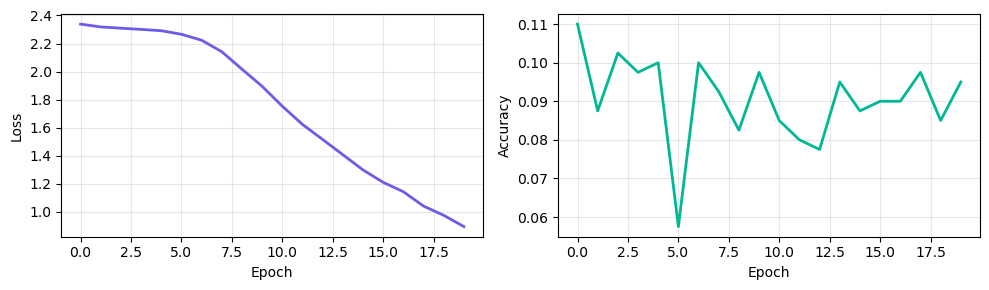

```
最终测试准确率: 9.500%
```

## 5. ViT 注意力可视化

> 看 ViT 的注意力关注图像的哪些区域

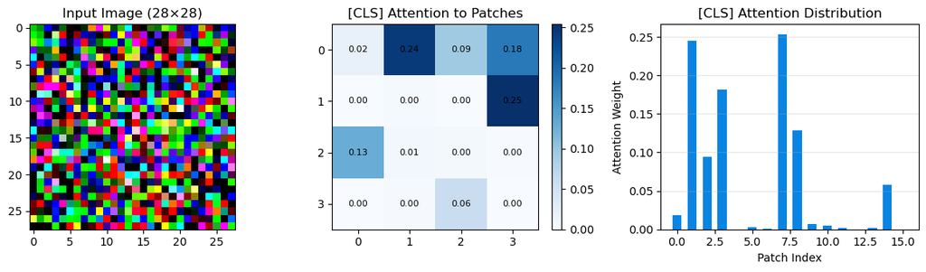

```
观察: [CLS] token 通过注意力聚合了所有 patch 的信息来做分类
```

## 6. ViT 的关键设计

### 为什么 ViT 有效

```
CNN 的问题:     感受野有限, 需要很多层才能看到全局
ViT 的优势:    第一层就能看到所有 patch, 全局注意力
ViT 的代价:    计算量 O(N^2), 大图 (384×384) 有 576 个 patch
              计算量是 CNN 的很多倍

所以:
  数据少 (< 1M 张) → CNN 更好 (ResNet / EfficientNet)
  数据多 (> 10M 张) → ViT 更好 (或 Swin / MAE)
```

### ViT 变体

| 模型 | 改进 |
| --- | --- |
| **ViT** | 原始版本, 全局注意力 |
| **DeiT** | 蒸馏 (CNN 教 ViT), 需要更少数据 |
| **Swin** | 窗口注意力 + 分层, 计算量 O(N) |
| **MAE** | 遮住部分 patch, 让 ViT 重建 (自监督) |
| **DINO** | ViT 自蒸馏, 无需标签 |

# Day 25 完成!

## 总结

| 概念 | 一句话 |
| --- | --- |
| **Patch Embedding** | 图像 → 固定大小 patch → 线性投影 → 序列 |
| **[CLS] Token** | 跟 BERT 一样, 聚合全局信息的特殊 token |
| **ViT = Transformer Encoder** | 没有卷积、没有 RNN, 全靠注意力 |
| **全局注意力** | 第一层就能看到整张图 |
| **数据需求** | 小数据 CNN 好, 大数据 ViT 好 |

## 作业 (2 题)

### 1. 改 patch 大小

**位置:** cell-7, `ViT(img_size=28, patch_size=7, ...)`

改成 `patch_size=14` (4 个 patch) 或 `patch_size=4` (49 个 patch)

- 参数量变化?
- 准确率变化?

**📖 答案**

patch_size=14: 只有 4 个 patch, 序列太短, 注意力优势发挥不出来 patch_size=4: 49 个 patch, 序列更长, 但计算量变 3 倍 原版 ViT 用 16×16 patch 在 224×224 上 = 196 个 patch patch 太大 → 丢失细节, patch 太小 → 计算量爆炸

### 2. 对比 CNN

**位置:** cell-10, ViT 训练代码

加一个简单的 2 层 CNN (Conv → Pool → Conv → Pool → FC), 在同样数据上对比准确率

**📖 答案**

随机数据上: CNN 可能比 ViT 好一点 (因为有归纳偏置) 真实数据上: 数据量少时 CNN 好, 数据量大时 ViT 好 ViT 论文结论: ImageNet (1.3M 张) 时 ViT ≈ ResNet JFT-300M (3 亿张) 时 ViT > ResNet